Reproducible Research: Peer Assessment 1 Por Ricardo Guerrero Hurtado

Prepare the Environment

```r
library(knitr)
opts_chunk$set(fig.path="figure/")
library(ggplot2)
opts_chunk$set(echo = TRUE, results = 'hold')
```

Loading and preprocessing the data

```r
if(!file.exists('activity.csv'))
    unzip('activity.zip')
myData <- read.csv("activity.csv")

#format the date
myData$date <- as.Date(myData$date, format="%Y-%m-%d")

#Create date/time column*-+

myData$date.time <- as.POSIXct(
    paste(myData$date, formatC(myData$interval/100, 2, format = "f")),
    format = "%Y-%m-%d %H.%M",
    tz = "GMT")

#Format the time
myData$time <- format(myData$date.time, format = "%H:%M:%S")
myData$time <- as.POSIXct(myData$time, format = "%H:%M:%S")

myData$interval <- as.factor(myData$interval)

days <- as.factor(myData$date)

intervals <- as.numeric(levels(myData$interval))
```

What is mean total number of steps taken per day?

Calculate the mean and median number of steps taken per day

```r
numSteps <- tapply(myData$steps, myData$date, sum, na.rm=TRUE)

mean(numSteps)
```

```
## [1] 9354.23
```

```r
median(numSteps)
```

```
## [1] 10395
```

Show a histogram of the total number of steps taken each day

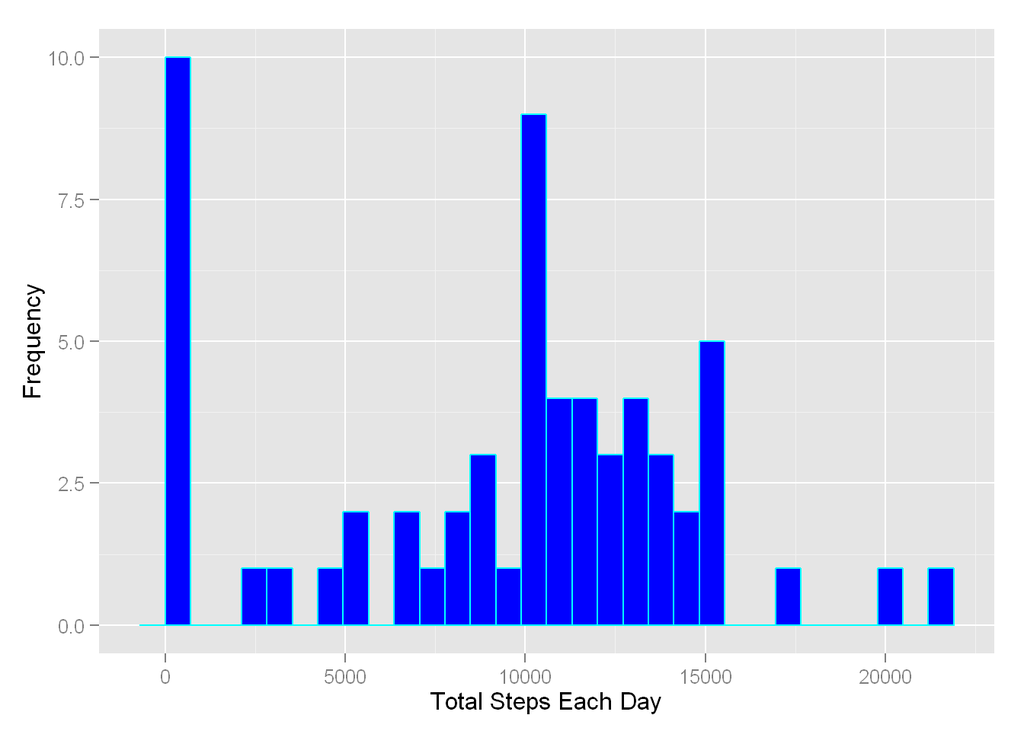

```r
qplot(
    numSteps,
    xlab='Total Steps Each Day',
    ylab='Frequency')+ geom_histogram(colour="cyan", fill="blue")
```

What is the average daily activity pattern?

Let’s make a time series plot of the 5 minute intervals (x axis) and the average number of steps taken, averaged across all days (y axis)

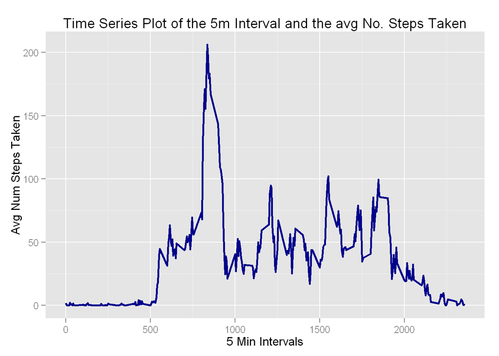

```r
#calculate the mean steps for each interval
avgSteps <- tapply(myData$steps, myData$time, mean, na.rm=TRUE)

#create date frame with mean steps
activityPattern <- data.frame(time=as.POSIXct(names(avgSteps)),
                            avgSteps=avgSteps)

myPlot <- ggplot(
        activityPattern,
        aes(intervals, avgSteps),
    )
myPlot +
    geom_line(color="darkblue", size=1) +
    ggtitle("Time Series Plot of the 5m Interval and the avg No. Steps Taken") +
    xlab("5 Min Intervals") +
    ylab("Avg Num Steps Taken")
```

Which 5-minute interval, on average across all the days in the dataset, contains the maximum number of steps?

```r
maxSteps <- which.max(activityPattern$avgSteps)

format(
    activityPattern[maxSteps, 'time'],
    format = "%H:%M"
    )
```

```
## [1] "08:35"
```

Imputing missing values

Find missing values:

```r
#find rows of missing values
sum(is.na(myData))
```

```
## [1] 2304
```

There are 2304 missing values in the dataset (total number of rows with “NAs”)

Fill in missing values; we’ll use the 5 minute interval mean to keep the data simliar

```r
#create a copy to preserve original
cleanData <- myData

cleanData$steps[is.na(cleanData$steps)] <-
    tapply(cleanData$steps, cleanData$interval, mean, na.rm = TRUE)

#compare the two
summary(myData)
```

```
##      steps             date               interval
##  Min.   :  0.00   Min.   :2012-10-01   0      :   61
##  1st Qu.:  0.00   1st Qu.:2012-10-16   5      :   61
##  Median :  0.00   Median :2012-10-31   10     :   61
##  Mean   : 37.38   Mean   :2012-10-31   15     :   61
##  3rd Qu.: 12.00   3rd Qu.:2012-11-15   20     :   61
##  Max.   :806.00   Max.   :2012-11-30   25     :   61
##  NA's   :2304                          (Other):17202
##    date.time                        time
##  Min.   :2012-10-01 00:00:00   Min.   :2015-05-17 00:00:00
##  1st Qu.:2012-10-16 05:58:45   1st Qu.:2015-05-17 05:58:45
##  Median :2012-10-31 11:57:30   Median :2015-05-17 11:57:30
##  Mean   :2012-10-31 11:57:30   Mean   :2015-05-17 11:57:30
##  3rd Qu.:2012-11-15 17:56:15   3rd Qu.:2015-05-17 17:56:15
##  Max.   :2012-11-30 23:55:00   Max.   :2015-05-17 23:55:00
##
```

Fill in missing values; we’ll use the 5 minute interval mean to keep the data simliar

```r
summary(cleanData)
```

```
##      steps             date               interval
##  Min.   :  0.00   Min.   :2012-10-01   0      :   61
##  1st Qu.:  0.00   1st Qu.:2012-10-16   5      :   61
##  Median :  0.00   Median :2012-10-31   10     :   61
##  Mean   : 37.38   Mean   :2012-10-31   15     :   61
##  3rd Qu.: 27.00   3rd Qu.:2012-11-15   20     :   61
##  Max.   :806.00   Max.   :2012-11-30   25     :   61
##                                        (Other):17202
##    date.time                        time
##  Min.   :2012-10-01 00:00:00   Min.   :2015-05-17 00:00:00
##  1st Qu.:2012-10-16 05:58:45   1st Qu.:2015-05-17 05:58:45
##  Median :2012-10-31 11:57:30   Median :2015-05-17 11:57:30
##  Mean   :2012-10-31 11:57:30   Mean   :2015-05-17 11:57:30
##  3rd Qu.:2012-11-15 17:56:15   3rd Qu.:2015-05-17 17:56:15
##  Max.   :2012-11-30 23:55:00   Max.   :2015-05-17 23:55:00
##
```

Histogram of the new Data Set:

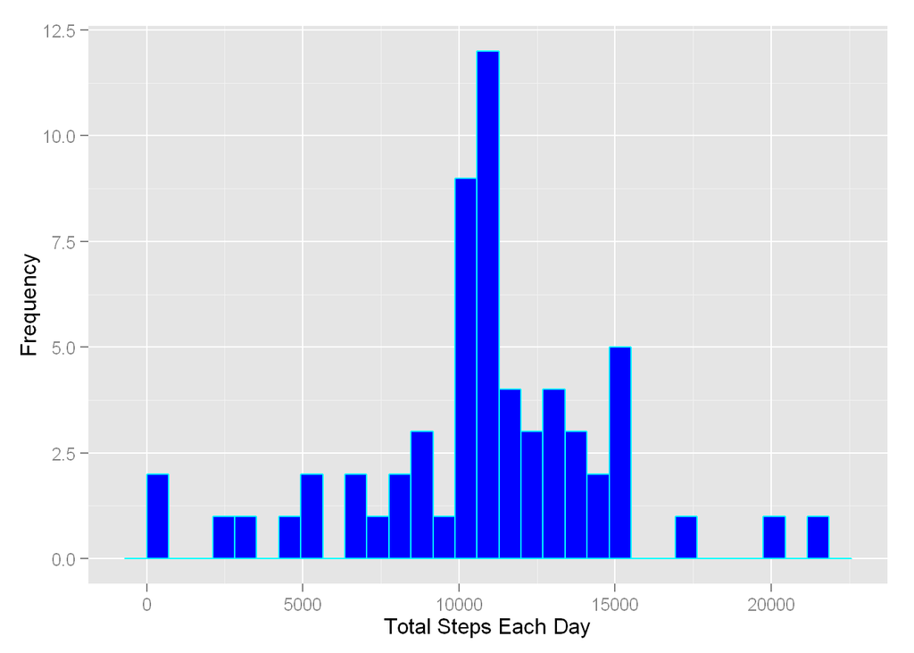

```r
cleanNumSteps <- tapply(cleanData$steps, cleanData$date, sum)

qplot(
    cleanNumSteps,
    xlab='Total Steps Each Day',
    ylab='Frequency')+ geom_histogram(colour="cyan", fill="blue")
```

```r
numSteps1 <- tapply(cleanData$steps, cleanData$date, sum, na.rm=TRUE)

mean(numSteps1)
```

```
## [1] 10766.19
```

```r
median(numSteps1)
```

```
## [1] 10766.19
```

Mean after populate missing values is 10766.19 Median populate missing values is 10766.19

What is the impact of imputing missing data on the estimates of the total daily number of steps?

Since our data has shown a t-student distribution (see both histograms), it seems that the impact of imputing missing values has increase our peak, but it’s not affect negatively our predictions.

Are there differences in activity patterns between weekdays and weekends?

Create a new factor variable in the dataset with two levels - “weekday” and “weekend” indicating whether a given date is a weekday or weekend day.

```r
#add Day to our cleanData
cleanData$Day <- weekdays(as.Date(as.character(cleanData$date)))

#add weekend value to our cleanData
cleanData$DayType <- as.factor(c("Weekend","Weekday"))

weekendDays <- cleanData$Day == "Saturday" | cleanData$Day == "Sunday"

cleanData$DayType[weekendDays] = "Weekend"
cleanData$DayType[!weekendDays] = "Weekday"


cleanAvgSteps <- tapply(cleanData$steps,
                        interaction(cleanData$time, cleanData$DayType),
                        mean)

cleanPattern <- data.frame(time=as.POSIXct(names(cleanAvgSteps)),
                           cleanAvgSteps = cleanAvgSteps,
                           DayType = as.factor(c("Weekend","Weekday")))
```

Make a panel plot containing a time series plot (i.e. type = “l”) of the 5-minute interval (x-axis) and the average number of steps taken, averaged across all weekday days or weekend days (y-axis).

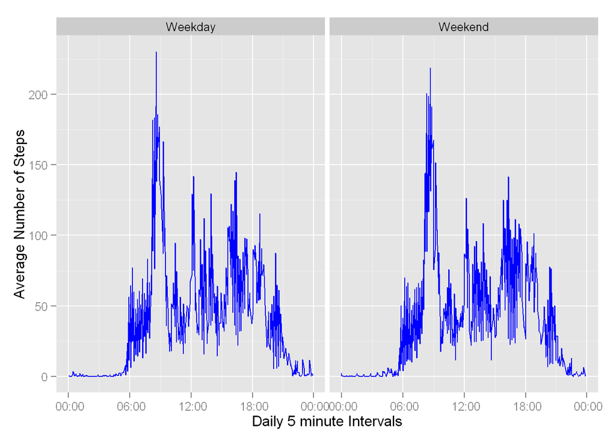

```r
library(scales)

ggplot(cleanPattern, aes(time, cleanAvgSteps)) +
    geom_line(color="blue") +
    xlab("Daily 5 minute Intervals") +
    ylab("Average Number of Steps") +
    scale_x_datetime(labels = date_format(format =' %H:%M')) +
    facet_grid(. ~ DayType)
```